# R Notebook

### 1. Loading Diamond Dataset

```r
data(diamonds)
names(diamonds)
```

```
 [1] "carat"   "cut"     "color"   "clarity" "depth"   "table"   "price"   "x"
 [9] "y"       "z"
```

### 2. create a scatterplot of price vs x. using the ggplot syntax.

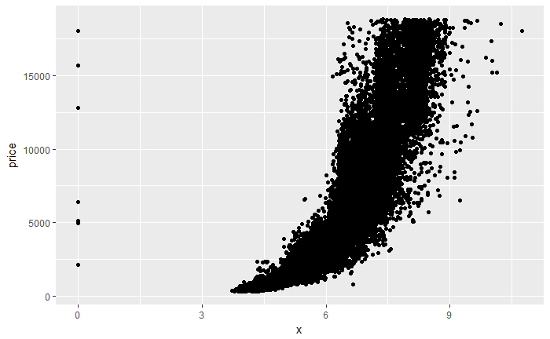

```r
ggplot(aes(x=x,y=price),data=diamonds)+
  geom_point()
```

### 3. What is the correlation between price and x,y,z?

```r
with(diamonds,cor.test(price,x))
```

```
    Pearson's product-moment correlation

data:  price and x
t = 440.16, df = 53938, p-value < 2.2e-16
alternative hypothesis: true correlation is not equal to 0
95 percent confidence interval:
 0.8825835 0.8862594
sample estimates:
      cor
0.8844352
```

```r
with(diamonds,cor.test(price,y))
```

```
    Pearson's product-moment correlation

data:  price and y
t = 401.14, df = 53938, p-value < 2.2e-16
alternative hypothesis: true correlation is not equal to 0
95 percent confidence interval:
 0.8632867 0.8675241
sample estimates:
      cor
0.8654209
```

```r
with(diamonds,cor.test(price,z))
```

```
    Pearson's product-moment correlation

data:  price and z
t = 393.6, df = 53938, p-value < 2.2e-16
alternative hypothesis: true correlation is not equal to 0
95 percent confidence interval:
 0.8590541 0.8634131
sample estimates:
      cor
0.8612494
```

### 4.Create a simple scatter plot of price vs depth.

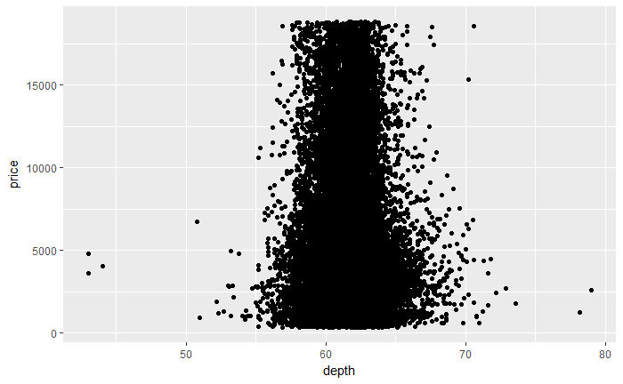

```r
ggplot(aes(x=depth,y=price),data=diamonds) +
  geom_point()
```

### 5.Change the code to make the transparency of the points to be 1/100 of what they are now and mark the x-axis every 2 units. See the instructor notes for two hints.

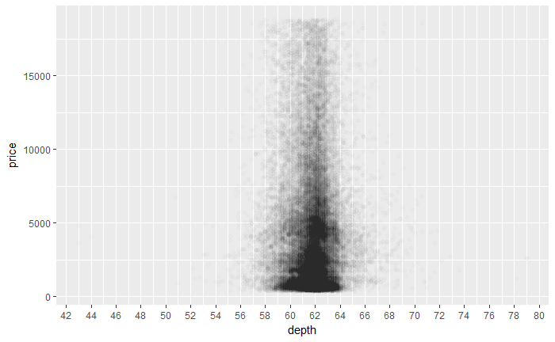

```r
ggplot(aes(x=depth,y=price),data=diamonds) +
  geom_point(alpha=1/100)+
  scale_x_continuous(breaks=seq(0,80,2))
```

### 6. Based on the scatterplot of depth vs price, most diamonds are between what values of depth?

Ans. 60 to 64

### 7. What is the correlation of depth vs price? Basedd on the correlation coefficient would you depth to predict the price of diamond?

```r
with(diamonds,cor.test(depth,price))
```

```
    Pearson's product-moment correlation

data:  depth and price
t = -2.473, df = 53938, p-value = 0.0134
alternative hypothesis: true correlation is not equal to 0
95 percent confidence interval:
 -0.019084756 -0.002208537
sample estimates:
       cor
-0.0106474
```

As the correlation coefficient value seems to very low, we can say that depth and price doesn’t have a strong relationship, So we cannot use the depth to predict the price of a diamond.

### 8. Create a scatterplot of price vs carat and omit the top 1% of price and carat values.

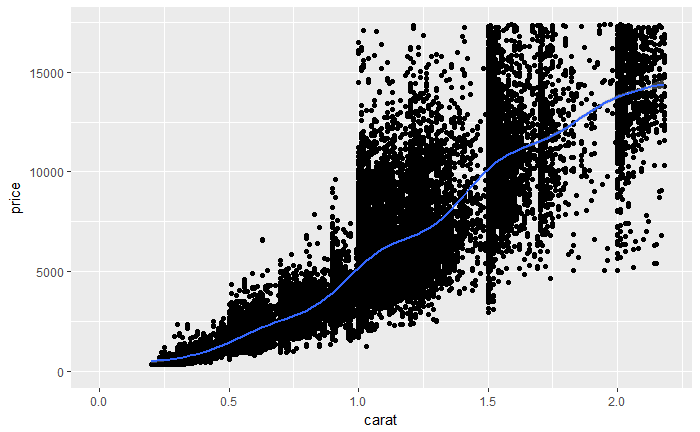

```r
ggplot(aes(x=carat,y=price),data=diamonds)+
  geom_point()+
  xlim(0,quantile(diamonds$carat,0.99))+
  ylim(0,quantile(diamonds$price,0.99))+
  geom_smooth()
```

### 9.Create a scatterplot of price vs. volume (x y z). This is a very rough approximation for a diamond’s volume.

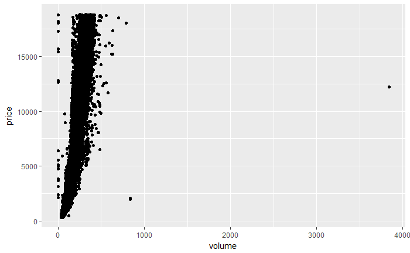

```r
diamonds$volume <- diamonds$x * diamonds$y * diamonds$z
ggplot(aes(x=volume,y=price),data=diamonds)+
  geom_point()
```

### 10.How many diamonds have zero volume?

```r
sum(diamonds$volume==0)
```

```
[1] 20
```

### 11.What is the correlation of price and volume? Exclude diamonds that have volume of zero or that are greater than or equal to 800.

```r
with(subset(diamonds,volume > 0 & volume <= 800),cor.test(price,volume))
```

```
    Pearson's product-moment correlation

data:  price and volume
t = 559.19, df = 53915, p-value < 2.2e-16
alternative hypothesis: true correlation is not equal to 0
95 percent confidence interval:
 0.9222944 0.9247772
sample estimates:
      cor
0.9235455
```

### 12.Subset the data to exclude diamonds with a volume greater than or equal to 800. Also, exclude diamonds with a volume of 0. Adjust the transparency of the points and add a linear model to the plot.

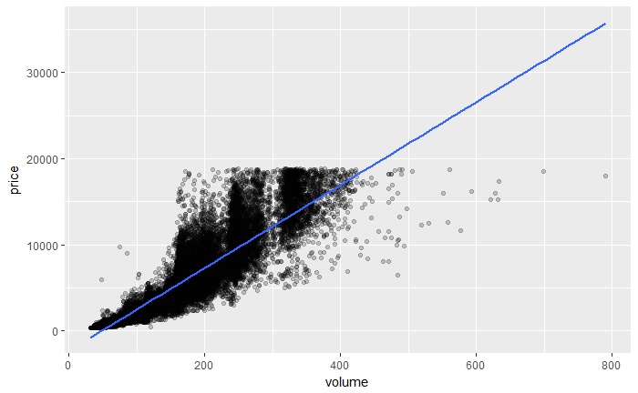

```r
ggplot(aes(x=volume,y=price),data=subset(diamonds,volume > 0 & volume <= 800))+
  geom_point(alpha=1/5)+
  geom_smooth(method = 'lm')
```

### 13.Use the function dplyr package to create a new data frame containing info on diamonds by clarity.

```r
library(dplyr)
diamonds_by_clarity <- group_by(diamonds,clarity)
diamondsByClarity <- summarise(diamonds_by_clarity,
                               mean_price = mean(price),
                               median_price = median(price),
                               min_price = min(price),
                               max_price = max(price),
                               n = n())
```

```r
diamonds_by_clarity <- group_by(diamonds, clarity)
diamonds_mp_by_clarity <- summarise(diamonds_by_clarity, mean_price = mean(price))
diamonds_by_color <- group_by(diamonds, color)
diamonds_mp_by_color <- summarise(diamonds_by_color, mean_price = mean(price))
```

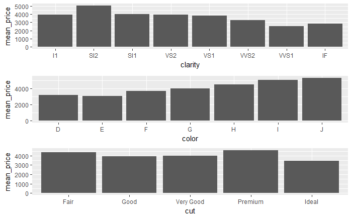

```r
library(gridExtra)
p1 <- ggplot(data=diamonds_mp_by_clarity,aes(x=clarity,y=mean_price))+
  geom_bar(stat = "identity")
p2 <- ggplot(data=diamonds_mp_by_color,aes(x=color,y=mean_price))+
  geom_bar(stat = "identity")
p3 <- ggplot(data=diamonds_mp_by_cut,aes(x=cut,y=mean_price))+
  geom_bar(stat = "identity")
grid.arrange(p1,p2,p3)
```